# wrangling_act55

[figure not shown]

## The dataset that we're going to be working on is WeRateDogs Twitter account. WeRateDogs is a Twitter account that rates people's dogs with a humorous comment about the dog. The account was started in 2015 by college student Matt Nelson, and has received international media attention both for its huge popularity.

### We will analyze the data in four steps:

#### 1- Gathering data

#### 2- Cleaning and handling

#### 3- Analysis and graphic visualizations

#### 4- Results

```python
#Request the necessary libraries

import datetime as dt
import numpy as np
import pandas as pd
import re
import requests
import seaborn as sns
import matplotlib.pyplot as plt
%matplotlib inline
%reload_ext autoreload
%autoreload 2
```

### 1) Gathering data:

```python
## Read the file
archive = pd.read_csv('twitter-archive-enhanced-2.csv')
archive.head(70)
```

|  | tweet_id | in_reply_to_status_id | in_reply_to_user_id | timestamp | source | text | retweeted_status_id | retweeted_status_user_id | retweeted_status_timestamp | expanded_urls | rating_numerator | rating_denominator | name | doggo | floofer | pupper | puppo |
| --- | --- | --- | --- | --- | --- | --- | --- | --- | --- | --- | --- | --- | --- | --- | --- | --- | --- |
| 0 | 892420643555336193 | NaN | NaN | 2017-08-01 16:23:56 +0000 | <a href="http://twitter.com/download/iphone" r... | This is Phineas. He's a mystical boy. Only eve... | NaN | NaN | NaN | https://twitter.com/dog_rates/status/892420643... | 13 | 10 | Phineas | None | None | None | None |
| 1 | 892177421306343426 | NaN | NaN | 2017-08-01 00:17:27 +0000 | <a href="http://twitter.com/download/iphone" r... | This is Tilly. She's just checking pup on you.... | NaN | NaN | NaN | https://twitter.com/dog_rates/status/892177421... | 13 | 10 | Tilly | None | None | None | None |
| 2 | 891815181378084864 | NaN | NaN | 2017-07-31 00:18:03 +0000 | <a href="http://twitter.com/download/iphone" r... | This is Archie. He is a rare Norwegian Pouncin... | NaN | NaN | NaN | https://twitter.com/dog_rates/status/891815181... | 12 | 10 | Archie | None | None | None | None |
| 3 | 891689557279858688 | NaN | NaN | 2017-07-30 15:58:51 +0000 | <a href="http://twitter.com/download/iphone" r... | This is Darla. She commenced a snooze mid meal... | NaN | NaN | NaN | https://twitter.com/dog_rates/status/891689557... | 13 | 10 | Darla | None | None | None | None |
| 4 | 891327558926688256 | NaN | NaN | 2017-07-29 16:00:24 +0000 | <a href="http://twitter.com/download/iphone" r... | This is Franklin. He would like you to stop ca... | NaN | NaN | NaN | https://twitter.com/dog_rates/status/891327558... | 12 | 10 | Franklin | None | None | None | None |
| ... | ... | ... | ... | ... | ... | ... | ... | ... | ... | ... | ... | ... | ... | ... | ... | ... | ... |
| 65 | 879492040517615616 | NaN | NaN | 2017-06-27 00:10:17 +0000 | <a href="http://twitter.com/download/iphone" r... | This is Bailey. He thinks you should measure e... | NaN | NaN | NaN | https://twitter.com/dog_rates/status/879492040... | 12 | 10 | Bailey | None | None | None | None |
| 66 | 879415818425184262 | NaN | NaN | 2017-06-26 19:07:24 +0000 | <a href="http://twitter.com/download/iphone" r... | This is Duddles. He did an attempt. 13/10 some... | NaN | NaN | NaN | https://twitter.com/dog_rates/status/879415818... | 13 | 10 | Duddles | None | None | None | None |
| 67 | 879376492567855104 | NaN | NaN | 2017-06-26 16:31:08 +0000 | <a href="http://twitter.com/download/iphone" r... | This is Jack AKA Stephen Furry. You're not sco... | NaN | NaN | NaN | https://twitter.com/dog_rates/status/879376492... | 12 | 10 | Jack | None | None | None | None |
| 68 | 879130579576475649 | NaN | NaN | 2017-06-26 00:13:58 +0000 | <a href="http://twitter.com/download/iphone" r... | RT @dog_rates: This is Emmy. She was adopted t... | 8.780576e+17 | 4.196984e+09 | 2017-06-23 01:10:23 +0000 | https://twitter.com/dog_rates/status/878057613... | 14 | 10 | Emmy | None | None | None | None |
| 69 | 879050749262655488 | NaN | NaN | 2017-06-25 18:56:45 +0000 | <a href="http://twitter.com/download/iphone" r... | This is Steven. He has trouble relating to oth... | NaN | NaN | NaN | https://twitter.com/dog_rates/status/879050749... | 11 | 10 | Steven | None | None | None | None |

70 rows × 17 columns

#### Browes more informations about our dateset

```python
#Browse columns and rows:

archive.shape
```

```
(2356, 17)
```

```python
archive.info()
```

```
<class 'pandas.core.frame.DataFrame'>
RangeIndex: 2356 entries, 0 to 2355
Data columns (total 17 columns):
 #   Column                      Non-Null Count  Dtype
---  ------                      --------------  -----
 0   tweet_id                    2356 non-null   int64
 1   in_reply_to_status_id       78 non-null     float64
 2   in_reply_to_user_id         78 non-null     float64
 3   timestamp                   2356 non-null   object
 4   source                      2356 non-null   object
 5   text                        2356 non-null   object
 6   retweeted_status_id         181 non-null    float64
 7   retweeted_status_user_id    181 non-null    float64
 8   retweeted_status_timestamp  181 non-null    object
 9   expanded_urls               2297 non-null   object
 10  rating_numerator            2356 non-null   int64
 11  rating_denominator          2356 non-null   int64
 12  name                        2356 non-null   object
 13  doggo                       2356 non-null   object
 14  floofer                     2356 non-null   object
 15  pupper                      2356 non-null   object
 16  puppo                       2356 non-null   object
dtypes: float64(4), int64(3), object(10)
memory usage: 313.0+ KB
```

```python
#Display the missing data
archive.isnull().sum()
```

```
tweet_id                         0
in_reply_to_status_id         2278
in_reply_to_user_id           2278
timestamp                        0
source                           0
text                             0
retweeted_status_id           2175
retweeted_status_user_id      2175
retweeted_status_timestamp    2175
expanded_urls                   59
rating_numerator                 0
rating_denominator               0
name                             0
doggo                            0
floofer                          0
pupper                           0
puppo                            0
dtype: int64
```

```python
# Display sample
tweet_sample = archive.iloc[2]
tweet_sample
```

```
tweet_id                                                     891815181378084864
in_reply_to_status_id                                                       NaN
in_reply_to_user_id                                                         NaN
timestamp                                             2017-07-31 00:18:03 +0000
source                        <a href="http://twitter.com/download/iphone" r...
text                          This is Archie. He is a rare Norwegian Pouncin...
retweeted_status_id                                                         NaN
retweeted_status_user_id                                                    NaN
retweeted_status_timestamp                                                  NaN
expanded_urls                 https://twitter.com/dog_rates/status/891815181...
rating_numerator                                                             12
rating_denominator                                                           10
name                                                                     Archie
doggo                                                                      None
floofer                                                                    None
pupper                                                                     None
puppo                                                                      None
Name: 2, dtype: object
```

```python
#Browse 'rating_numerator', 'rating_denominator' describe:

archive[['rating_numerator', 'rating_denominator']].describe()
```

|  | rating_numerator | rating_denominator |
| --- | --- | --- |
| count | 2356.000000 | 2356.000000 |
| mean | 13.126486 | 10.455433 |
| std | 45.876648 | 6.745237 |
| min | 0.000000 | 0.000000 |
| 25% | 10.000000 | 10.000000 |
| 50% | 11.000000 | 10.000000 |
| 75% | 12.000000 | 10.000000 |
| max | 1776.000000 | 170.000000 |

## Image predictions

```python
 # Open the file
tsv_url = "https://d17h27t6h515a5.cloudfront.net/topher/2017/August/599fd2ad_image-predictions/image-predictions.tsv"
r = requests.get(tsv_url)

with open(tsv_url.split('/')[-1], mode = 'wb') as file:
    file.write(r.content)
```

```python
# Reading the file
images = pd.read_csv('image-predictions.tsv', sep = '\t')
images.head()
```

|  | tweet_id | jpg_url | img_num | p1 | p1_conf | p1_dog | p2 | p2_conf | p2_dog | p3 | p3_conf | p3_dog |
| --- | --- | --- | --- | --- | --- | --- | --- | --- | --- | --- | --- | --- |
| 0 | 666020888022790149 | https://pbs.twimg.com/media/CT4udn0WwAA0aMy.jpg | 1 | Welsh_springer_spaniel | 0.465074 | True | collie | 0.156665 | True | Shetland_sheepdog | 0.061428 | True |
| 1 | 666029285002620928 | https://pbs.twimg.com/media/CT42GRgUYAA5iDo.jpg | 1 | redbone | 0.506826 | True | miniature_pinscher | 0.074192 | True | Rhodesian_ridgeback | 0.072010 | True |
| 2 | 666033412701032449 | https://pbs.twimg.com/media/CT4521TWwAEvMyu.jpg | 1 | German_shepherd | 0.596461 | True | malinois | 0.138584 | True | bloodhound | 0.116197 | True |
| 3 | 666044226329800704 | https://pbs.twimg.com/media/CT5Dr8HUEAA-lEu.jpg | 1 | Rhodesian_ridgeback | 0.408143 | True | redbone | 0.360687 | True | miniature_pinscher | 0.222752 | True |
| 4 | 666049248165822465 | https://pbs.twimg.com/media/CT5IQmsXIAAKY4A.jpg | 1 | miniature_pinscher | 0.560311 | True | Rottweiler | 0.243682 | True | Doberman | 0.154629 | True |

#### Browes more informations about our dateset

```python
#Browse columns and rows:
images.shape
```

```
(2075, 12)
```

```python
images.info()
```

```
<class 'pandas.core.frame.DataFrame'>
RangeIndex: 2075 entries, 0 to 2074
Data columns (total 12 columns):
 #   Column    Non-Null Count  Dtype
---  ------    --------------  -----
 0   tweet_id  2075 non-null   int64
 1   jpg_url   2075 non-null   object
 2   img_num   2075 non-null   int64
 3   p1        2075 non-null   object
 4   p1_conf   2075 non-null   float64
 5   p1_dog    2075 non-null   bool
 6   p2        2075 non-null   object
 7   p2_conf   2075 non-null   float64
 8   p2_dog    2075 non-null   bool
 9   p3        2075 non-null   object
 10  p3_conf   2075 non-null   float64
 11  p3_dog    2075 non-null   bool
dtypes: bool(3), float64(3), int64(2), object(4)
memory usage: 152.1+ KB
```

```python
# display missing data
images.isnull().sum()
```

```
tweet_id    0
jpg_url     0
img_num     0
p1          0
p1_conf     0
p1_dog      0
p2          0
p2_conf     0
p2_dog      0
p3          0
p3_conf     0
p3_dog      0
dtype: int64
```

```python
# Display sample
image_sample = images.iloc[2]
image_sample
```

```
tweet_id                                 666033412701032449
jpg_url     https://pbs.twimg.com/media/CT4521TWwAEvMyu.jpg
img_num                                                   1
p1                                          German_shepherd
p1_conf                                            0.596461
p1_dog                                                 True
p2                                                 malinois
p2_conf                                            0.138584
p2_dog                                                 True
p3                                               bloodhound
p3_conf                                            0.116197
p3_dog                                                 True
Name: 2, dtype: object
```

### tweet_json.txt

**Code:** here the basic code to Query Twitter API from udacity

import tweepy from tweepy import OAuthHandler import json from timeit import default_timer as timer

##### Query Twitter API for each tweet in the Twitter archive and save JSON in a text file

##### These are hidden to comply with Twitter's API terms and conditions

consumer_key = 'HIDDEN' consumer_secret = 'HIDDEN' access_token = 'HIDDEN' access_secret = 'HIDDEN'

auth = OAuthHandler(consumer_key, consumer_secret) auth.set_access_token(access_token, access_secret)

api = tweepy.API(auth, wait_on_rate_limit=True)

##### NOTE TO STUDENT WITH MOBILE VERIFICATION ISSUES:

##### df_1 is a DataFrame with the twitter_archive_enhanced.csv file. You may have to

##### change line 17 to match the name of your DataFrame with twitter_archive_enhanced.csv

##### NOTE TO REVIEWER: this student had mobile verification issues so the following

##### Twitter API code was sent to this student from a Udacity instructor

##### Tweet IDs for which to gather additional data via Twitter's API

tweet_ids = df_1.tweet_id.values len(tweet_ids)

##### Query Twitter's API for JSON data for each tweet ID in the Twitter archive

count = 0 fails_dict = {} start = timer()

##### Save each tweet's returned JSON as a new line in a .txt file

with open('tweet_json.txt', 'w') as outfile:

```
# This loop will likely take 20-30 minutes to run because of Twitter's rate limit
for tweet_id in tweet_ids:
    count += 1
    print(str(count) + ": " + str(tweet_id))
    try:
        tweet = api.get_status(tweet_id, tweet_mode='extended')
        print("Success")
        json.dump(tweet._json, outfile)
        outfile.write('\n')
    except tweepy.TweepError as e:
        print("Fail")
        fails_dict[tweet_id] = e
        pass
```

end = timer() print(end - start) print(fails_dict)

```python
# Reading the file
tweet_json = pd.read_json('tweet_json.txt',lines = True)
tweet_json.head()
```

|  | created_at | id | id_str | full_text | truncated | display_text_range | entities | extended_entities | source | in_reply_to_status_id | ... | favorite_count | favorited | retweeted | possibly_sensitive | possibly_sensitive_appealable | lang | retweeted_status | quoted_status_id | quoted_status_id_str | quoted_status |
| --- | --- | --- | --- | --- | --- | --- | --- | --- | --- | --- | --- | --- | --- | --- | --- | --- | --- | --- | --- | --- | --- |
| 0 | 2017-08-01 16:23:56+00:00 | 892420643555336193 | 892420643555336192 | This is Phineas. He's a mystical boy. Only eve... | False | [0, 85] | {'hashtags': [], 'symbols': [], 'user_mentions... | {'media': [{'id': 892420639486877696, 'id_str'... | <a href="http://twitter.com/download/iphone" r... | NaN | ... | 39467 | False | False | 0.0 | 0.0 | en | NaN | NaN | NaN | NaN |
| 1 | 2017-08-01 00:17:27+00:00 | 892177421306343426 | 892177421306343424 | This is Tilly. She's just checking pup on you.... | False | [0, 138] | {'hashtags': [], 'symbols': [], 'user_mentions... | {'media': [{'id': 892177413194625024, 'id_str'... | <a href="http://twitter.com/download/iphone" r... | NaN | ... | 33819 | False | False | 0.0 | 0.0 | en | NaN | NaN | NaN | NaN |
| 2 | 2017-07-31 00:18:03+00:00 | 891815181378084864 | 891815181378084864 | This is Archie. He is a rare Norwegian Pouncin... | False | [0, 121] | {'hashtags': [], 'symbols': [], 'user_mentions... | {'media': [{'id': 891815175371796480, 'id_str'... | <a href="http://twitter.com/download/iphone" r... | NaN | ... | 25461 | False | False | 0.0 | 0.0 | en | NaN | NaN | NaN | NaN |
| 3 | 2017-07-30 15:58:51+00:00 | 891689557279858688 | 891689557279858688 | This is Darla. She commenced a snooze mid meal... | False | [0, 79] | {'hashtags': [], 'symbols': [], 'user_mentions... | {'media': [{'id': 891689552724799489, 'id_str'... | <a href="http://twitter.com/download/iphone" r... | NaN | ... | 42908 | False | False | 0.0 | 0.0 | en | NaN | NaN | NaN | NaN |
| 4 | 2017-07-29 16:00:24+00:00 | 891327558926688256 | 891327558926688256 | This is Franklin. He would like you to stop ca... | False | [0, 138] | {'hashtags': [{'text': 'BarkWeek', 'indices': ... | {'media': [{'id': 891327551943041024, 'id_str'... | <a href="http://twitter.com/download/iphone" r... | NaN | ... | 41048 | False | False | 0.0 | 0.0 | en | NaN | NaN | NaN | NaN |

5 rows × 31 columns

#### Browes more informations about our dateset

```python
tweet_json.info()
```

```
<class 'pandas.core.frame.DataFrame'>
RangeIndex: 2354 entries, 0 to 2353
Data columns (total 31 columns):
 #   Column                         Non-Null Count  Dtype
---  ------                         --------------  -----
 0   created_at                     2354 non-null   datetime64[ns, UTC]
 1   id                             2354 non-null   int64
 2   id_str                         2354 non-null   int64
 3   full_text                      2354 non-null   object
 4   truncated                      2354 non-null   bool
 5   display_text_range             2354 non-null   object
 6   entities                       2354 non-null   object
 7   extended_entities              2073 non-null   object
 8   source                         2354 non-null   object
 9   in_reply_to_status_id          78 non-null     float64
```

[output cut: 23 more lines]

```python
# Browes the describe
tweet_json.describe()
```

|  | id | id_str | in_reply_to_status_id | in_reply_to_status_id_str | in_reply_to_user_id | in_reply_to_user_id_str | geo | coordinates | contributors | retweet_count | favorite_count | possibly_sensitive | possibly_sensitive_appealable | quoted_status_id | quoted_status_id_str |
| --- | --- | --- | --- | --- | --- | --- | --- | --- | --- | --- | --- | --- | --- | --- | --- |
| count | 2.354000e+03 | 2.354000e+03 | 7.800000e+01 | 7.800000e+01 | 7.800000e+01 | 7.800000e+01 | 0.0 | 0.0 | 0.0 | 2354.000000 | 2354.000000 | 2211.0 | 2211.0 | 2.900000e+01 | 2.900000e+01 |
| mean | 7.426978e+17 | 7.426978e+17 | 7.455079e+17 | 7.455079e+17 | 2.014171e+16 | 2.014171e+16 | NaN | NaN | NaN | 3164.797366 | 8080.968564 | 0.0 | 0.0 | 8.162686e+17 | 8.162686e+17 |
| std | 6.852812e+16 | 6.852812e+16 | 7.582492e+16 | 7.582492e+16 | 1.252797e+17 | 1.252797e+17 | NaN | NaN | NaN | 5284.770364 | 11814.771334 | 0.0 | 0.0 | 6.164161e+16 | 6.164161e+16 |
| min | 6.660209e+17 | 6.660209e+17 | 6.658147e+17 | 6.658147e+17 | 1.185634e+07 | 1.185634e+07 | NaN | NaN | NaN | 0.000000 | 0.000000 | 0.0 | 0.0 | 6.721083e+17 | 6.721083e+17 |
| 25% | 6.783975e+17 | 6.783975e+17 | 6.757419e+17 | 6.757419e+17 | 3.086374e+08 | 3.086374e+08 | NaN | NaN | NaN | 624.500000 | 1415.000000 | 0.0 | 0.0 | 7.888183e+17 | 7.888183e+17 |
| 50% | 7.194596e+17 | 7.194596e+17 | 7.038708e+17 | 7.038708e+17 | 4.196984e+09 | 4.196984e+09 | NaN | NaN | NaN | 1473.500000 | 3603.500000 | 0.0 | 0.0 | 8.340867e+17 | 8.340867e+17 |
| 75% | 7.993058e+17 | 7.993058e+17 | 8.257804e+17 | 8.257804e+17 | 4.196984e+09 | 4.196984e+09 | NaN | NaN | NaN | 3652.000000 | 10122.250000 | 0.0 | 0.0 | 8.664587e+17 | 8.664587e+17 |
| max | 8.924206e+17 | 8.924206e+17 | 8.862664e+17 | 8.862664e+17 | 8.405479e+17 | 8.405479e+17 | NaN | NaN | NaN | 79515.000000 | 132810.000000 | 0.0 | 0.0 | 8.860534e+17 | 8.860534e+17 |

```python
# display missing data

tweet_json.isnull().sum()
```

```
created_at                          0
id                                  0
id_str                              0
full_text                           0
truncated                           0
display_text_range                  0
entities                            0
extended_entities                 281
source                              0
in_reply_to_status_id            2276
in_reply_to_status_id_str        2276
in_reply_to_user_id              2276
in_reply_to_user_id_str          2276
in_reply_to_screen_name          2276
user                                0
geo                              2354
coordinates                      2354
place                            2353
contributors                     2354
is_quote_status                     0
retweet_count                       0
favorite_count                      0
favorited                           0
retweeted                           0
possibly_sensitive                143
possibly_sensitive_appealable     143
lang                                0
retweeted_status                 2175
quoted_status_id                 2325
quoted_status_id_str             2325
quoted_status                    2326
dtype: int64
```

```python
# Browes sample
json_sample = tweet_json.iloc[2]
json_sample
```

```
created_at                                               2017-07-31 00:18:03+00:00
id                                                              891815181378084864
id_str                                                          891815181378084864
full_text                        This is Archie. He is a rare Norwegian Pouncin...
truncated                                                                    False
display_text_range                                                        [0, 121]
entities                         {'hashtags': [], 'symbols': [], 'user_mentions...
extended_entities                {'media': [{'id': 891815175371796480, 'id_str'...
source                           <a href="http://twitter.com/download/iphone" r...
in_reply_to_status_id                                                          NaN
in_reply_to_status_id_str                                                      NaN
in_reply_to_user_id                                                            NaN
in_reply_to_user_id_str                                                        NaN
in_reply_to_screen_name                                                       None
user                             {'id': 4196983835, 'id_str': '4196983835', 'na...
geo                                                                            NaN
coordinates                                                                    NaN
place                                                                         None
contributors                                                                   NaN
is_quote_status                                                              False
retweet_count                                                                 4328
favorite_count                                                               25461
favorited                                                                    False
retweeted                                                                    False
possibly_sensitive                                                               0
possibly_sensitive_appealable                                                    0
lang                                                                            en
retweeted_status                                                               NaN
quoted_status_id                                                               NaN
quoted_status_id_str                                                           NaN
quoted_status                                                                  NaN
Name: 2, dtype: object
```

### Assessing data:

### Twitter archive :

### Data quality issues:

**1- There is missing data in the "in_reply_to_status_id", "in_reply_to_user_id", "ret_status_id", "retweet_status_user_id", "ret_status_timestamp" and "expand_urls" columns**

**2- There are some columns that will not help me in the analysis**

**3- The source column must be reformatted**

**4- There is values of "None" in the name column.**

**5- Numerator with Denominator values is incorrect.**

### Tidiness issues:

**1- All columns [doggo / floofer / pupper / puppo] must be merge into one column to be classified.**

**2- We want to add a new column containing the gender classification.**

### Data quality issues:

**1- There is duplicate data in the jpg_url column.**

**2- There are some columns that will not help me in the analysis.**

### Tidiness issues:

**1- We have to change the columns type (p1, p2 and p3) to categoral datatype.**

### Data quality issues:

**1- There is missing data in the columns:'in_reply_to_status_id', 'in_reply_to_status_id_str', 'in_reply_to_user_id', 'in_reply_to_user_id_str', 'in_reply_to_screen_name', 'geo','coordinates','place','contributors','retweeted_status', 'quoted_status_id','quoted_status_id_str','quoted_status','possibly_sensitive', 'lang','possibly_sensitive_appealable','is_quote_status','favorited','retweeted', 'display_text_range','truncated','extended_entities','entities','user','entities','extended_entities'**

**3- The 'source' column needs to be reformatted**

**4- There are some columns that will not help me in the analysis**

### Tidiness issues:

**1) we need to change the name of column (id) to (tweet_id)**

## Total Issues that we discovered:

### - 4 Tidiness issues

### Now, we will clean the data so that we can complete the analysis

```python
#First make a copy for our three dataframes
twitter_archive_cleaned = archive.copy(deep=True)
images_cleaned = images.copy(deep=True)
tweet_json_cleaned = tweet_json.copy(deep=True)
```

### 1- twitter_archive_cleaned

```python
# Write the code
twitter_archive_cleaned.reset_index(inplace=True, drop=True)
```

```python
#Drop unnecessary columns
twitter_archive_cleaned = twitter_archive_cleaned[pd.isnull(twitter_archive_cleaned.retweeted_status_id)]
twitter_archive_cleaned=twitter_archive_cleaned.drop(['in_reply_to_status_id', 'in_reply_to_user_id', 'retweeted_status_id',
            'retweeted_status_user_id', 'retweeted_status_timestamp', 'expanded_urls'], axis=1)
```

```python
#Drop (tweet_id )duplicated
twitter_archive_cleaned.tweet_id.duplicated().sum()
twitter_archive_cleaned= archive.drop_duplicates(subset=["tweet_id"])
```

```python
# remove all rows that have values in the following columns
# Write the code

twitter_archive_cleaned = twitter_archive_cleaned[twitter_archive_cleaned.retweeted_status_id.isnull()]
twitter_archive_cleaned = twitter_archive_cleaned[twitter_archive_cleaned.retweeted_status_user_id.isnull()]
twitter_archive_cleaned = twitter_archive_cleaned[twitter_archive_cleaned.retweeted_status_timestamp.isnull()]
```

```python
# Write the code
twitter_archive_cleaned['retweeted_status_timestamp'] = pd.to_datetime(twitter_archive_cleaned.timestamp)
twitter_archive_cleaned['timestamp'] = pd.to_datetime(twitter_archive_cleaned.timestamp)
twitter_archive_cleaned['tweet_id'] = twitter_archive_cleaned['tweet_id'].astype('str')
```

```python
# define a new cloumn
# Write the code

breeds = ['doggo', 'pupper','floofer', 'puppo']
column = [i for i in twitter_archive_cleaned.columns.tolist() if i not in breeds]


twitter_archive_cleaned = pd.melt(twitter_archive_cleaned, id_vars = column, value_vars = breeds,
                         var_name = 'breeds', value_name = 'dog_breed')
# Delete column 'breeds'
twitter_archive_cleaned = twitter_archive_cleaned.drop('breeds', 1)
```

```python
# Replace nan value
twitter_archive_cleaned =  twitter_archive_cleaned.replace('None', np.nan)
```

```python
# check
twitter_archive_cleaned
```

|  | tweet_id | in_reply_to_status_id | in_reply_to_user_id | timestamp | source | text | retweeted_status_id | retweeted_status_user_id | retweeted_status_timestamp | expanded_urls | rating_numerator | rating_denominator | name | dog_breed |
| --- | --- | --- | --- | --- | --- | --- | --- | --- | --- | --- | --- | --- | --- | --- |
| 0 | 892420643555336193 | NaN | NaN | 2017-08-01 16:23:56+00:00 | <a href="http://twitter.com/download/iphone" r... | This is Phineas. He's a mystical boy. Only eve... | NaN | NaN | 2017-08-01 16:23:56+00:00 | https://twitter.com/dog_rates/status/892420643... | 13 | 10 | Phineas | NaN |
| 1 | 892177421306343426 | NaN | NaN | 2017-08-01 00:17:27+00:00 | <a href="http://twitter.com/download/iphone" r... | This is Tilly. She's just checking pup on you.... | NaN | NaN | 2017-08-01 00:17:27+00:00 | https://twitter.com/dog_rates/status/892177421... | 13 | 10 | Tilly | NaN |
| 2 | 891815181378084864 | NaN | NaN | 2017-07-31 00:18:03+00:00 | <a href="http://twitter.com/download/iphone" r... | This is Archie. He is a rare Norwegian Pouncin... | NaN | NaN | 2017-07-31 00:18:03+00:00 | https://twitter.com/dog_rates/status/891815181... | 12 | 10 | Archie | NaN |
| 3 | 891689557279858688 | NaN | NaN | 2017-07-30 15:58:51+00:00 | <a href="http://twitter.com/download/iphone" r... | This is Darla. She commenced a snooze mid meal... | NaN | NaN | 2017-07-30 15:58:51+00:00 | https://twitter.com/dog_rates/status/891689557... | 13 | 10 | Darla | NaN |
| 4 | 891327558926688256 | NaN | NaN | 2017-07-29 16:00:24+00:00 | <a href="http://twitter.com/download/iphone" r... | This is Franklin. He would like you to stop ca... | NaN | NaN | 2017-07-29 16:00:24+00:00 | https://twitter.com/dog_rates/status/891327558... | 12 | 10 | Franklin | NaN |
| ... | ... | ... | ... | ... | ... | ... | ... | ... | ... | ... | ... | ... | ... | ... |
| 8695 | 666049248165822465 | NaN | NaN | 2015-11-16 00:24:50+00:00 | <a href="http://twitter.com/download/iphone" r... | Here we have a 1949 1st generation vulpix. Enj... | NaN | NaN | 2015-11-16 00:24:50+00:00 | https://twitter.com/dog_rates/status/666049248... | 5 | 10 | NaN | NaN |
| 8696 | 666044226329800704 | NaN | NaN | 2015-11-16 00:04:52+00:00 | <a href="http://twitter.com/download/iphone" r... | This is a purebred Piers Morgan. Loves to Netf... | NaN | NaN | 2015-11-16 00:04:52+00:00 | https://twitter.com/dog_rates/status/666044226... | 6 | 10 | a | NaN |
| 8697 | 666033412701032449 | NaN | NaN | 2015-11-15 23:21:54+00:00 | <a href="http://twitter.com/download/iphone" r... | Here is a very happy pup. Big fan of well-main... | NaN | NaN | 2015-11-15 23:21:54+00:00 | https://twitter.com/dog_rates/status/666033412... | 9 | 10 | a | NaN |
| 8698 | 666029285002620928 | NaN | NaN | 2015-11-15 23:05:30+00:00 | <a href="http://twitter.com/download/iphone" r... | This is a western brown Mitsubishi terrier. Up... | NaN | NaN | 2015-11-15 23:05:30+00:00 | https://twitter.com/dog_rates/status/666029285... | 7 | 10 | a | NaN |
| 8699 | 666020888022790149 | NaN | NaN | 2015-11-15 22:32:08+00:00 | <a href="http://twitter.com/download/iphone" r... | Here we have a Japanese Irish Setter. Lost eye... | NaN | NaN | 2015-11-15 22:32:08+00:00 | https://twitter.com/dog_rates/status/666020888... | 8 | 10 | NaN | NaN |

8700 rows × 14 columns

```python
# double check
twitter_archive_cleaned.info()
```

```
<class 'pandas.core.frame.DataFrame'>
RangeIndex: 8700 entries, 0 to 8699
Data columns (total 14 columns):
 #   Column                      Non-Null Count  Dtype
---  ------                      --------------  -----
 0   tweet_id                    8700 non-null   object
 1   in_reply_to_status_id       312 non-null    float64
 2   in_reply_to_user_id         312 non-null    float64
 3   timestamp                   8700 non-null   datetime64[ns, UTC]
 4   source                      8700 non-null   object
 5   text                        8700 non-null   object
 6   retweeted_status_id         0 non-null      float64
 7   retweeted_status_user_id    0 non-null      float64
 8   retweeted_status_timestamp  8700 non-null   datetime64[ns, UTC]
 9   expanded_urls               8468 non-null   object
 10  rating_numerator            8700 non-null   int64
 11  rating_denominator          8700 non-null   int64
 12  name                        5980 non-null   object
 13  dog_breed                   356 non-null    object
dtypes: datetime64[ns, UTC](2), float64(4), int64(2), object(6)
memory usage: 951.7+ KB
```

```python
# count the 'dog breed'
twitter_archive_cleaned.dog_breed.value_counts()
```

```
pupper     234
doggo       87
puppo       25
floofer     10
Name: dog_breed, dtype: int64
```

```python
# clean tags
def remove_tags(text):
     return href_tags.sub('', text)

href_tags = re.compile(r'<[^>]+>')
twitter_archive_cleaned['source'] = twitter_archive_cleaned['source'].apply(remove_tags)
```

```python
# Check
twitter_archive_cleaned['source']
```

```
0       Twitter for iPhone
1       Twitter for iPhone
2       Twitter for iPhone
3       Twitter for iPhone
4       Twitter for iPhone
               ...
8695    Twitter for iPhone
8696    Twitter for iPhone
8697    Twitter for iPhone
8698    Twitter for iPhone
8699    Twitter for iPhone
Name: source, Length: 8700, dtype: object
```

```python
# Count the values in the source column
twitter_archive_cleaned.source.value_counts()
```

```
Twitter for iPhone     8168
Vine - Make a Scene     364
Twitter Web Client      124
TweetDeck                44
Name: source, dtype: int64
```

```python
# check
twitter_archive_cleaned.info()
```

```
<class 'pandas.core.frame.DataFrame'>
RangeIndex: 8700 entries, 0 to 8699
Data columns (total 14 columns):
 #   Column                      Non-Null Count  Dtype
---  ------                      --------------  -----
 0   tweet_id                    8700 non-null   object
 1   in_reply_to_status_id       312 non-null    float64
 2   in_reply_to_user_id         312 non-null    float64
 3   timestamp                   8700 non-null   datetime64[ns, UTC]
 4   source                      8700 non-null   object
 5   text                        8700 non-null   object
 6   retweeted_status_id         0 non-null      float64
 7   retweeted_status_user_id    0 non-null      float64
 8   retweeted_status_timestamp  8700 non-null   datetime64[ns, UTC]
 9   expanded_urls               8468 non-null   object
 10  rating_numerator            8700 non-null   int64
 11  rating_denominator          8700 non-null   int64
 12  name                        5980 non-null   object
 13  dog_breed                   356 non-null    object
dtypes: datetime64[ns, UTC](2), float64(4), int64(2), object(6)
memory usage: 951.7+ KB
```

```python
# fix the 'rating_denominator'
twitter_archive_cleaned.rating_denominator.value_counts(ascending=False, dropna=False)
```

```
10     8612
50       12
80        8
20        8
11        8
15        4
16        4
40        4
120       4
2         4
90        4
7         4
130       4
170       4
70        4
110       4
150       4
0         4
Name: rating_denominator, dtype: int64
```

```python
#Find all denominators that are not equal to 10
clean_denominators = twitter_archive_cleaned[twitter_archive_cleaned.rating_denominator != 10]
```

```python
# Write the code

counter = 0
for text in clean_denominators.text:
    counter += 1
    print(counter,') ',text,'\n',sep = '')
```

```
1) @jonnysun @Lin_Manuel ok jomny I know you're excited but 960/00 isn't a valid rating, 13/10 is tho

2) @docmisterio account started on 11/15/15

3) The floofs have been released I repeat the floofs have been released. 84/70 https://t.co/NIYC820tmd

4) Meet Sam. She smiles 24/7 &amp; secretly aspires to be a reindeer.
Keep Sam smiling by clicking and sharing this link:
https://t.co/98tB8y7y7t https://t.co/LouL5vdvxx

5) Why does this never happen at my front door... 165/150 https://t.co/HmwrdfEfUE

6) After so many requests, this is Bretagne. She was the last surviving 9/11 search dog, and our second ever 14/10. RIP https://t.co/XAVDNDaVgQ

7) Say hello to this unbelievably well behaved squad of doggos. 204/170 would try to pet all at once https://t.co/yGQI3He3xv

8) Happy 4/20 from the squad! 13/10 for all https://t.co/eV1diwds8a

9) This is Bluebert. He just saw that both #FinalFur match ups are split 50/50. Amazed af. 11/10 https://t.co/Kky1DPG4iq

10) Happy Saturday here's 9 puppers on a bench. 99/90 good work everybody https://t.co/mpvaVxKmc1

11) Here's a brigade of puppers. All look very prepared for whatever happens next. 80/80 https://t.co/0eb7R1Om12

12) From left to right:
Cletus, Jerome, Alejandro, Burp, &amp; Titson
None know where camera is. 45/50 would hug all at once https://t.co/sedre1ivTK

13) Here is a whole flock of puppers.  60/50 I'll take the lot https://t.co/9dpcw6MdWa

14) Happy Wednesday here's a bucket of pups. 44/40 would pet all at once https://t.co/HppvrYuamZ

15) Yes I do realize a rating of 4/20 would've been fitting. However, it would be unjust to give these cooperative pups that low of a rating

16) Two sneaky puppers were not initially seen, moving the rating to 143/130. Please forgive us. Thank you https://t.co/kRK51Y5ac3

17) Someone help the girl is being mugged. Several are distracting her while two steal her shoes. Clever puppers 121/110 https://t.co/1zfnTJLt55

18) This is Darrel. He just robbed a 7/11 and is in a high speed police chase. Was just spotted by the helicopter 10/10 https://t.co/7EsP8LmSp5

```

[output cut: 136 more lines]

```
81) Yes I do realize a rating of 4/20 would've been fitting. However, it would be unjust to give these cooperative pups that low of a rating

82) Two sneaky puppers were not initially seen, moving the rating to 143/130. Please forgive us. Thank you https://t.co/kRK51Y5ac3

83) Someone help the girl is being mugged. Several are distracting her while two steal her shoes. Clever puppers 121/110 https://t.co/1zfnTJLt55

84) This is Darrel. He just robbed a 7/11 and is in a high speed police chase. Was just spotted by the helicopter 10/10 https://t.co/7EsP8LmSp5

85) I'm aware that I could've said 20/16, but here at WeRateDogs we are very professional. An inconsistent rating scale is simply irresponsible

86) IT'S PUPPERGEDDON. Total of 144/120 ...I think https://t.co/ZanVtAtvIq

87) Here we have an entire platoon of puppers. Total score: 88/80 would pet all at once https://t.co/y93p6FLvVw

88) This is an Albanian 3 1/2 legged  Episcopalian. Loves well-polished hardwood flooring. Penis on the collar. 9/10 https://t.co/d9NcXFKwLv
```

```python
# fix the rating_numerator
twitter_archive_cleaned.rating_numerator.value_counts(ascending=False)
```

```
12      2000
10      1768
11      1704
13      1228
9        624
8        392
7        216
14       172
5        144
6        128
3         76
4         68
2         36
1         32
0          8
```

[output cut: 26 more lines]

```python
#Find all Tweets with rating numerators more than 20
clean_numerators = twitter_archive_cleaned[twitter_archive_cleaned.rating_numerator > 20]
```

```python
# Write the code

counter = 0
for text in clean_numerators.text:
    counter += 1
    print(counter,') ',text,'\n',sep = '')
```

```
1) @dhmontgomery We also gave snoop dogg a 420/10 but I think that predated your research

2) @s8n You tried very hard to portray this good boy as not so good, but you have ultimately failed. His goodness shines through. 666/10

3) @markhoppus 182/10

4) @jonnysun @Lin_Manuel ok jomny I know you're excited but 960/00 isn't a valid rating, 13/10 is tho

5) The floofs have been released I repeat the floofs have been released. 84/70 https://t.co/NIYC820tmd

6) Meet Sam. She smiles 24/7 &amp; secretly aspires to be a reindeer.
Keep Sam smiling by clicking and sharing this link:
https://t.co/98tB8y7y7t https://t.co/LouL5vdvxx

7) This is Logan, the Chow who lived. He solemnly swears he's up to lots of good. H*ckin magical af 9.75/10 https://t.co/yBO5wuqaPS

8) This is Sophie. She's a Jubilant Bush Pupper. Super h*ckin rare. Appears at random just to smile at the locals. 11.27/10 would smile back https://t.co/QFaUiIHxHq

9) Why does this never happen at my front door... 165/150 https://t.co/HmwrdfEfUE

10) This is Atticus. He's quite simply America af. 1776/10 https://t.co/GRXwMxLBkh

11) Say hello to this unbelievably well behaved squad of doggos. 204/170 would try to pet all at once https://t.co/yGQI3He3xv

12) This is Bluebert. He just saw that both #FinalFur match ups are split 50/50. Amazed af. 11/10 https://t.co/Kky1DPG4iq

13) Happy Saturday here's 9 puppers on a bench. 99/90 good work everybody https://t.co/mpvaVxKmc1

14) Here's a brigade of puppers. All look very prepared for whatever happens next. 80/80 https://t.co/0eb7R1Om12

15) From left to right:
Cletus, Jerome, Alejandro, Burp, &amp; Titson
None know where camera is. 45/50 would hug all at once https://t.co/sedre1ivTK

16) Here is a whole flock of puppers.  60/50 I'll take the lot https://t.co/9dpcw6MdWa

17) Happy Wednesday here's a bucket of pups. 44/40 would pet all at once https://t.co/HppvrYuamZ

18) Two sneaky puppers were not initially seen, moving the rating to 143/130. Please forgive us. Thank you https://t.co/kRK51Y5ac3

```

[output cut: 152 more lines]

```
86) Happy Wednesday here's a bucket of pups. 44/40 would pet all at once https://t.co/HppvrYuamZ

87) Two sneaky puppers were not initially seen, moving the rating to 143/130. Please forgive us. Thank you https://t.co/kRK51Y5ac3

88) Someone help the girl is being mugged. Several are distracting her while two steal her shoes. Clever puppers 121/110 https://t.co/1zfnTJLt55

89) Here we have uncovered an entire battalion of holiday puppers. Average of 11.26/10 https://t.co/eNm2S6p9BD

90) IT'S PUPPERGEDDON. Total of 144/120 ...I think https://t.co/ZanVtAtvIq

91) Here we have an entire platoon of puppers. Total score: 88/80 would pet all at once https://t.co/y93p6FLvVw

92) After so many requests... here you go.

Good dogg. 420/10 https://t.co/yfAAo1gdeY
```

```python
# Write the code

twitter_archive_cleaned[twitter_archive_cleaned.text.str.contains(r"(\d+\.\d*\/\d+)")]
```

|  | tweet_id | in_reply_to_status_id | in_reply_to_user_id | timestamp | source | text | retweeted_status_id | retweeted_status_user_id | retweeted_status_timestamp | expanded_urls | rating_numerator | rating_denominator | name | dog_breed |
| --- | --- | --- | --- | --- | --- | --- | --- | --- | --- | --- | --- | --- | --- | --- |
| 42 | 883482846933004288 | NaN | NaN | 2017-07-08 00:28:19+00:00 | Twitter for iPhone | This is Bella. She hopes her smile made you sm... | NaN | NaN | 2017-07-08 00:28:19+00:00 | https://twitter.com/dog_rates/status/883482846... | 5 | 10 | Bella | NaN |
| 558 | 786709082849828864 | NaN | NaN | 2016-10-13 23:23:56+00:00 | Twitter for iPhone | This is Logan, the Chow who lived. He solemnly... | NaN | NaN | 2016-10-13 23:23:56+00:00 | https://twitter.com/dog_rates/status/786709082... | 75 | 10 | Logan | NaN |
| 617 | 778027034220126208 | NaN | NaN | 2016-09-20 00:24:34+00:00 | Twitter for iPhone | This is Sophie. She's a Jubilant Bush Pupper. ... | NaN | NaN | 2016-09-20 00:24:34+00:00 | https://twitter.com/dog_rates/status/778027034... | 27 | 10 | Sophie | NaN |
| 1510 | 681340665377193984 | 6.813394e+17 | 4.196984e+09 | 2015-12-28 05:07:27+00:00 | Twitter for iPhone | I've been told there's a slight possibility he... | NaN | NaN | 2015-12-28 05:07:27+00:00 | NaN | 5 | 10 | NaN | NaN |
| 1533 | 680494726643068929 | NaN | NaN | 2015-12-25 21:06:00+00:00 | Twitter for iPhone | Here we have uncovered an entire battalion of ... | NaN | NaN | 2015-12-25 21:06:00+00:00 | https://twitter.com/dog_rates/status/680494726... | 26 | 10 | NaN | NaN |
| 2217 | 883482846933004288 | NaN | NaN | 2017-07-08 00:28:19+00:00 | Twitter for iPhone | This is Bella. She hopes her smile made you sm... | NaN | NaN | 2017-07-08 00:28:19+00:00 | https://twitter.com/dog_rates/status/883482846... | 5 | 10 | Bella | NaN |
| 2733 | 786709082849828864 | NaN | NaN | 2016-10-13 23:23:56+00:00 | Twitter for iPhone | This is Logan, the Chow who lived. He solemnly... | NaN | NaN | 2016-10-13 23:23:56+00:00 | https://twitter.com/dog_rates/status/786709082... | 75 | 10 | Logan | NaN |
| 2792 | 778027034220126208 | NaN | NaN | 2016-09-20 00:24:34+00:00 | Twitter for iPhone | This is Sophie. She's a Jubilant Bush Pupper. ... | NaN | NaN | 2016-09-20 00:24:34+00:00 | https://twitter.com/dog_rates/status/778027034... | 27 | 10 | Sophie | pupper |
| 3685 | 681340665377193984 | 6.813394e+17 | 4.196984e+09 | 2015-12-28 05:07:27+00:00 | Twitter for iPhone | I've been told there's a slight possibility he... | NaN | NaN | 2015-12-28 05:07:27+00:00 | NaN | 5 | 10 | NaN | NaN |
| 3708 | 680494726643068929 | NaN | NaN | 2015-12-25 21:06:00+00:00 | Twitter for iPhone | Here we have uncovered an entire battalion of ... | NaN | NaN | 2015-12-25 21:06:00+00:00 | https://twitter.com/dog_rates/status/680494726... | 26 | 10 | NaN | NaN |
| 4392 | 883482846933004288 | NaN | NaN | 2017-07-08 00:28:19+00:00 | Twitter for iPhone | This is Bella. She hopes her smile made you sm... | NaN | NaN | 2017-07-08 00:28:19+00:00 | https://twitter.com/dog_rates/status/883482846... | 5 | 10 | Bella | NaN |
| 4908 | 786709082849828864 | NaN | NaN | 2016-10-13 23:23:56+00:00 | Twitter for iPhone | This is Logan, the Chow who lived. He solemnly... | NaN | NaN | 2016-10-13 23:23:56+00:00 | https://twitter.com/dog_rates/status/786709082... | 75 | 10 | Logan | NaN |
| 4967 | 778027034220126208 | NaN | NaN | 2016-09-20 00:24:34+00:00 | Twitter for iPhone | This is Sophie. She's a Jubilant Bush Pupper. ... | NaN | NaN | 2016-09-20 00:24:34+00:00 | https://twitter.com/dog_rates/status/778027034... | 27 | 10 | Sophie | NaN |
| 5860 | 681340665377193984 | 6.813394e+17 | 4.196984e+09 | 2015-12-28 05:07:27+00:00 | Twitter for iPhone | I've been told there's a slight possibility he... | NaN | NaN | 2015-12-28 05:07:27+00:00 | NaN | 5 | 10 | NaN | NaN |
| 5883 | 680494726643068929 | NaN | NaN | 2015-12-25 21:06:00+00:00 | Twitter for iPhone | Here we have uncovered an entire battalion of ... | NaN | NaN | 2015-12-25 21:06:00+00:00 | https://twitter.com/dog_rates/status/680494726... | 26 | 10 | NaN | NaN |
| 6567 | 883482846933004288 | NaN | NaN | 2017-07-08 00:28:19+00:00 | Twitter for iPhone | This is Bella. She hopes her smile made you sm... | NaN | NaN | 2017-07-08 00:28:19+00:00 | https://twitter.com/dog_rates/status/883482846... | 5 | 10 | Bella | NaN |
| 7083 | 786709082849828864 | NaN | NaN | 2016-10-13 23:23:56+00:00 | Twitter for iPhone | This is Logan, the Chow who lived. He solemnly... | NaN | NaN | 2016-10-13 23:23:56+00:00 | https://twitter.com/dog_rates/status/786709082... | 75 | 10 | Logan | NaN |
| 7142 | 778027034220126208 | NaN | NaN | 2016-09-20 00:24:34+00:00 | Twitter for iPhone | This is Sophie. She's a Jubilant Bush Pupper. ... | NaN | NaN | 2016-09-20 00:24:34+00:00 | https://twitter.com/dog_rates/status/778027034... | 27 | 10 | Sophie | NaN |
| 8035 | 681340665377193984 | 6.813394e+17 | 4.196984e+09 | 2015-12-28 05:07:27+00:00 | Twitter for iPhone | I've been told there's a slight possibility he... | NaN | NaN | 2015-12-28 05:07:27+00:00 | NaN | 5 | 10 | NaN | NaN |
| 8058 | 680494726643068929 | NaN | NaN | 2015-12-25 21:06:00+00:00 | Twitter for iPhone | Here we have uncovered an entire battalion of ... | NaN | NaN | 2015-12-25 21:06:00+00:00 | https://twitter.com/dog_rates/status/680494726... | 26 | 10 | NaN | NaN |

```python
# Write the code

twitter_archive_cleaned['rating_numerator'] = twitter_archive_cleaned['rating_numerator'].astype('float')
twitter_archive_cleaned['rating_denominator'] = twitter_archive_cleaned['rating_denominator'].astype('float')
```

```python
# Write the code

twitter_archive_cleaned.loc[(twitter_archive_cleaned['tweet_id'] == 883482846933004288) & (twitter_archive_cleaned['rating_numerator'] == 5), ['rating_numerator']] = 13.5
twitter_archive_cleaned.loc[(twitter_archive_cleaned['tweet_id'] == 832215909146226688) & (twitter_archive_cleaned['rating_numerator'] == 27), ['rating_numerator']] = 11.27
twitter_archive_cleaned.loc[(twitter_archive_cleaned['tweet_id'] == 786709082849828864) & (twitter_archive_cleaned['rating_numerator'] == 75), ['rating_numerator']] = 9.75
twitter_archive_cleaned.loc[(twitter_archive_cleaned['tweet_id'] == 778027034220126208) & (twitter_archive_cleaned['rating_numerator'] == 27), ['rating_numerator']] = 11.27
twitter_archive_cleaned.loc[(twitter_archive_cleaned['tweet_id'] == 680494726643068929) & (twitter_archive_cleaned['rating_numerator'] == 26), ['rating_numerator']] = 11.26
```

```python
# Write the code

twitter_archive_cleaned[twitter_archive_cleaned.text.str.contains(r"(\d+\.\d*\/\d+)")]
```

|  | tweet_id | in_reply_to_status_id | in_reply_to_user_id | timestamp | source | text | retweeted_status_id | retweeted_status_user_id | retweeted_status_timestamp | expanded_urls | rating_numerator | rating_denominator | name | dog_breed |
| --- | --- | --- | --- | --- | --- | --- | --- | --- | --- | --- | --- | --- | --- | --- |
| 42 | 883482846933004288 | NaN | NaN | 2017-07-08 00:28:19+00:00 | Twitter for iPhone | This is Bella. She hopes her smile made you sm... | NaN | NaN | 2017-07-08 00:28:19+00:00 | https://twitter.com/dog_rates/status/883482846... | 5.0 | 10.0 | Bella | NaN |
| 558 | 786709082849828864 | NaN | NaN | 2016-10-13 23:23:56+00:00 | Twitter for iPhone | This is Logan, the Chow who lived. He solemnly... | NaN | NaN | 2016-10-13 23:23:56+00:00 | https://twitter.com/dog_rates/status/786709082... | 75.0 | 10.0 | Logan | NaN |
| 617 | 778027034220126208 | NaN | NaN | 2016-09-20 00:24:34+00:00 | Twitter for iPhone | This is Sophie. She's a Jubilant Bush Pupper. ... | NaN | NaN | 2016-09-20 00:24:34+00:00 | https://twitter.com/dog_rates/status/778027034... | 27.0 | 10.0 | Sophie | NaN |
| 1510 | 681340665377193984 | 6.813394e+17 | 4.196984e+09 | 2015-12-28 05:07:27+00:00 | Twitter for iPhone | I've been told there's a slight possibility he... | NaN | NaN | 2015-12-28 05:07:27+00:00 | NaN | 5.0 | 10.0 | NaN | NaN |
| 1533 | 680494726643068929 | NaN | NaN | 2015-12-25 21:06:00+00:00 | Twitter for iPhone | Here we have uncovered an entire battalion of ... | NaN | NaN | 2015-12-25 21:06:00+00:00 | https://twitter.com/dog_rates/status/680494726... | 26.0 | 10.0 | NaN | NaN |
| 2217 | 883482846933004288 | NaN | NaN | 2017-07-08 00:28:19+00:00 | Twitter for iPhone | This is Bella. She hopes her smile made you sm... | NaN | NaN | 2017-07-08 00:28:19+00:00 | https://twitter.com/dog_rates/status/883482846... | 5.0 | 10.0 | Bella | NaN |
| 2733 | 786709082849828864 | NaN | NaN | 2016-10-13 23:23:56+00:00 | Twitter for iPhone | This is Logan, the Chow who lived. He solemnly... | NaN | NaN | 2016-10-13 23:23:56+00:00 | https://twitter.com/dog_rates/status/786709082... | 75.0 | 10.0 | Logan | NaN |
| 2792 | 778027034220126208 | NaN | NaN | 2016-09-20 00:24:34+00:00 | Twitter for iPhone | This is Sophie. She's a Jubilant Bush Pupper. ... | NaN | NaN | 2016-09-20 00:24:34+00:00 | https://twitter.com/dog_rates/status/778027034... | 27.0 | 10.0 | Sophie | pupper |
| 3685 | 681340665377193984 | 6.813394e+17 | 4.196984e+09 | 2015-12-28 05:07:27+00:00 | Twitter for iPhone | I've been told there's a slight possibility he... | NaN | NaN | 2015-12-28 05:07:27+00:00 | NaN | 5.0 | 10.0 | NaN | NaN |
| 3708 | 680494726643068929 | NaN | NaN | 2015-12-25 21:06:00+00:00 | Twitter for iPhone | Here we have uncovered an entire battalion of ... | NaN | NaN | 2015-12-25 21:06:00+00:00 | https://twitter.com/dog_rates/status/680494726... | 26.0 | 10.0 | NaN | NaN |
| 4392 | 883482846933004288 | NaN | NaN | 2017-07-08 00:28:19+00:00 | Twitter for iPhone | This is Bella. She hopes her smile made you sm... | NaN | NaN | 2017-07-08 00:28:19+00:00 | https://twitter.com/dog_rates/status/883482846... | 5.0 | 10.0 | Bella | NaN |
| 4908 | 786709082849828864 | NaN | NaN | 2016-10-13 23:23:56+00:00 | Twitter for iPhone | This is Logan, the Chow who lived. He solemnly... | NaN | NaN | 2016-10-13 23:23:56+00:00 | https://twitter.com/dog_rates/status/786709082... | 75.0 | 10.0 | Logan | NaN |
| 4967 | 778027034220126208 | NaN | NaN | 2016-09-20 00:24:34+00:00 | Twitter for iPhone | This is Sophie. She's a Jubilant Bush Pupper. ... | NaN | NaN | 2016-09-20 00:24:34+00:00 | https://twitter.com/dog_rates/status/778027034... | 27.0 | 10.0 | Sophie | NaN |
| 5860 | 681340665377193984 | 6.813394e+17 | 4.196984e+09 | 2015-12-28 05:07:27+00:00 | Twitter for iPhone | I've been told there's a slight possibility he... | NaN | NaN | 2015-12-28 05:07:27+00:00 | NaN | 5.0 | 10.0 | NaN | NaN |
| 5883 | 680494726643068929 | NaN | NaN | 2015-12-25 21:06:00+00:00 | Twitter for iPhone | Here we have uncovered an entire battalion of ... | NaN | NaN | 2015-12-25 21:06:00+00:00 | https://twitter.com/dog_rates/status/680494726... | 26.0 | 10.0 | NaN | NaN |
| 6567 | 883482846933004288 | NaN | NaN | 2017-07-08 00:28:19+00:00 | Twitter for iPhone | This is Bella. She hopes her smile made you sm... | NaN | NaN | 2017-07-08 00:28:19+00:00 | https://twitter.com/dog_rates/status/883482846... | 5.0 | 10.0 | Bella | NaN |
| 7083 | 786709082849828864 | NaN | NaN | 2016-10-13 23:23:56+00:00 | Twitter for iPhone | This is Logan, the Chow who lived. He solemnly... | NaN | NaN | 2016-10-13 23:23:56+00:00 | https://twitter.com/dog_rates/status/786709082... | 75.0 | 10.0 | Logan | NaN |
| 7142 | 778027034220126208 | NaN | NaN | 2016-09-20 00:24:34+00:00 | Twitter for iPhone | This is Sophie. She's a Jubilant Bush Pupper. ... | NaN | NaN | 2016-09-20 00:24:34+00:00 | https://twitter.com/dog_rates/status/778027034... | 27.0 | 10.0 | Sophie | NaN |
| 8035 | 681340665377193984 | 6.813394e+17 | 4.196984e+09 | 2015-12-28 05:07:27+00:00 | Twitter for iPhone | I've been told there's a slight possibility he... | NaN | NaN | 2015-12-28 05:07:27+00:00 | NaN | 5.0 | 10.0 | NaN | NaN |
| 8058 | 680494726643068929 | NaN | NaN | 2015-12-25 21:06:00+00:00 | Twitter for iPhone | Here we have uncovered an entire battalion of ... | NaN | NaN | 2015-12-25 21:06:00+00:00 | https://twitter.com/dog_rates/status/680494726... | 26.0 | 10.0 | NaN | NaN |

```python
# Save the file after cleaning
twitter_archive_cleaned.csv= twitter_archive_cleaned.to_csv('data_archive.csv', index=False)
```

### 2- images_cleaned

```python
# Display how much duplicate data  there are
images_cleaned.jpg_url.duplicated().sum()
```

```
66
```

```python
# Drop 'jpg_url'
images_cleaned=images_cleaned.drop_duplicates(subset=["jpg_url"])
images_cleaned
```

|  | tweet_id | jpg_url | img_num | p1 | p1_conf | p1_dog | p2 | p2_conf | p2_dog | p3 | p3_conf | p3_dog |
| --- | --- | --- | --- | --- | --- | --- | --- | --- | --- | --- | --- | --- |
| 0 | 666020888022790149 | https://pbs.twimg.com/media/CT4udn0WwAA0aMy.jpg | 1 | Welsh_springer_spaniel | 0.465074 | True | collie | 0.156665 | True | Shetland_sheepdog | 0.061428 | True |
| 1 | 666029285002620928 | https://pbs.twimg.com/media/CT42GRgUYAA5iDo.jpg | 1 | redbone | 0.506826 | True | miniature_pinscher | 0.074192 | True | Rhodesian_ridgeback | 0.072010 | True |
| 2 | 666033412701032449 | https://pbs.twimg.com/media/CT4521TWwAEvMyu.jpg | 1 | German_shepherd | 0.596461 | True | malinois | 0.138584 | True | bloodhound | 0.116197 | True |
| 3 | 666044226329800704 | https://pbs.twimg.com/media/CT5Dr8HUEAA-lEu.jpg | 1 | Rhodesian_ridgeback | 0.408143 | True | redbone | 0.360687 | True | miniature_pinscher | 0.222752 | True |
| 4 | 666049248165822465 | https://pbs.twimg.com/media/CT5IQmsXIAAKY4A.jpg | 1 | miniature_pinscher | 0.560311 | True | Rottweiler | 0.243682 | True | Doberman | 0.154629 | True |
| ... | ... | ... | ... | ... | ... | ... | ... | ... | ... | ... | ... | ... |
| 2070 | 891327558926688256 | https://pbs.twimg.com/media/DF6hr6BUMAAzZgT.jpg | 2 | basset | 0.555712 | True | English_springer | 0.225770 | True | German_short-haired_pointer | 0.175219 | True |
| 2071 | 891689557279858688 | https://pbs.twimg.com/media/DF_q7IAWsAEuuN8.jpg | 1 | paper_towel | 0.170278 | False | Labrador_retriever | 0.168086 | True | spatula | 0.040836 | False |
| 2072 | 891815181378084864 | https://pbs.twimg.com/media/DGBdLU1WsAANxJ9.jpg | 1 | Chihuahua | 0.716012 | True | malamute | 0.078253 | True | kelpie | 0.031379 | True |
| 2073 | 892177421306343426 | https://pbs.twimg.com/media/DGGmoV4XsAAUL6n.jpg | 1 | Chihuahua | 0.323581 | True | Pekinese | 0.090647 | True | papillon | 0.068957 | True |
| 2074 | 892420643555336193 | https://pbs.twimg.com/media/DGKD1-bXoAAIAUK.jpg | 1 | orange | 0.097049 | False | bagel | 0.085851 | False | banana | 0.076110 | False |

2009 rows × 12 columns

```python
# Rename the following columns :
images_cleaned.rename(columns={'p1': 'Prediction1', 'p2': 'Prediction2', 'p3': 'Prediction3'}, inplace=True)
images_cleaned.rename(columns={'p1_conf': 'Prediction1_conf', 'p1_dog': 'Prediction1_dog'}, inplace=True)
images_cleaned.rename(columns={'p2_conf': 'Prediction2_conf', 'p2_dog': 'Prediction2_dog'}, inplace=True)
images_cleaned.rename(columns={'p3_conf': 'Prediction3_conf', 'p3_dog': 'Prediction3_dog'}, inplace=True)
```

```python
# Check
images_cleaned.info()
```

```
<class 'pandas.core.frame.DataFrame'>
Int64Index: 2009 entries, 0 to 2074
Data columns (total 12 columns):
 #   Column            Non-Null Count  Dtype
---  ------            --------------  -----
 0   tweet_id          2009 non-null   int64
 1   jpg_url           2009 non-null   object
 2   img_num           2009 non-null   int64
 3   Prediction1       2009 non-null   object
 4   Prediction1_conf  2009 non-null   float64
 5   Prediction1_dog   2009 non-null   bool
 6   Prediction2       2009 non-null   object
 7   Prediction2_conf  2009 non-null   float64
 8   Prediction2_dog   2009 non-null   bool
 9   Prediction3       2009 non-null   object
 10  Prediction3_conf  2009 non-null   float64
 11  Prediction3_dog   2009 non-null   bool
dtypes: bool(3), float64(3), int64(2), object(4)
memory usage: 162.8+ KB
```

```python
# Write the code

images_cleaned['tweet_id'] = images_cleaned['tweet_id'].astype('str')
```

```python
# Save the file after cleaning
images_cleaned=images_cleaned.to_csv('data_image.csv', index=False)
```

## 3- tweet_json_cleaned

```python
# Drop unnecessary columns
tweet_json_cleaned=tweet_json_cleaned.drop(['in_reply_to_status_id', 'in_reply_to_status_id_str', 'in_reply_to_user_id',
            'in_reply_to_user_id_str', 'in_reply_to_screen_name', 'geo',
                       'coordinates','place','contributors','retweeted_status',
                          'quoted_status_id','quoted_status_id_str','quoted_status',
                          'possibly_sensitive','lang','possibly_sensitive_appealable',
                          'is_quote_status','favorited','retweeted','display_text_range',
                          'truncated','extended_entities','entities','user','entities','extended_entities'], axis=1)
```

```python
# Clean tags

def remove_tags(text):
     return href_tags.sub('', text)

href_tags = re.compile(r'<[^>]+>')
tweet_json_cleaned['source'] = tweet_json_cleaned['source'].apply(remove_tags)
```

```python
# check
tweet_json_cleaned['source']
```

```
0       Twitter for iPhone
1       Twitter for iPhone
2       Twitter for iPhone
3       Twitter for iPhone
4       Twitter for iPhone
               ...
2349    Twitter for iPhone
2350    Twitter for iPhone
2351    Twitter for iPhone
2352    Twitter for iPhone
2353    Twitter for iPhone
Name: source, Length: 2354, dtype: object
```

```python
# rename 'id' column to'tweet_id'
tweet_json_cleaned = tweet_json_cleaned.rename(columns={'id':'tweet_id'})
tweet_json_cleaned
```

|  | created_at | tweet_id | id_str | full_text | source | retweet_count | favorite_count |
| --- | --- | --- | --- | --- | --- | --- | --- |
| 0 | 2017-08-01 16:23:56+00:00 | 892420643555336193 | 892420643555336192 | This is Phineas. He's a mystical boy. Only eve... | Twitter for iPhone | 8853 | 39467 |
| 1 | 2017-08-01 00:17:27+00:00 | 892177421306343426 | 892177421306343424 | This is Tilly. She's just checking pup on you.... | Twitter for iPhone | 6514 | 33819 |
| 2 | 2017-07-31 00:18:03+00:00 | 891815181378084864 | 891815181378084864 | This is Archie. He is a rare Norwegian Pouncin... | Twitter for iPhone | 4328 | 25461 |
| 3 | 2017-07-30 15:58:51+00:00 | 891689557279858688 | 891689557279858688 | This is Darla. She commenced a snooze mid meal... | Twitter for iPhone | 8964 | 42908 |
| 4 | 2017-07-29 16:00:24+00:00 | 891327558926688256 | 891327558926688256 | This is Franklin. He would like you to stop ca... | Twitter for iPhone | 9774 | 41048 |
| ... | ... | ... | ... | ... | ... | ... | ... |
| 2349 | 2015-11-16 00:24:50+00:00 | 666049248165822465 | 666049248165822464 | Here we have a 1949 1st generation vulpix. Enj... | Twitter for iPhone | 41 | 111 |
| 2350 | 2015-11-16 00:04:52+00:00 | 666044226329800704 | 666044226329800704 | This is a purebred Piers Morgan. Loves to Netf... | Twitter for iPhone | 147 | 311 |
| 2351 | 2015-11-15 23:21:54+00:00 | 666033412701032449 | 666033412701032448 | Here is a very happy pup. Big fan of well-main... | Twitter for iPhone | 47 | 128 |
| 2352 | 2015-11-15 23:05:30+00:00 | 666029285002620928 | 666029285002620928 | This is a western brown Mitsubishi terrier. Up... | Twitter for iPhone | 48 | 132 |
| 2353 | 2015-11-15 22:32:08+00:00 | 666020888022790149 | 666020888022790144 | Here we have a Japanese Irish Setter. Lost eye... | Twitter for iPhone | 532 | 2535 |

2354 rows × 7 columns

```python
# Write the code

tweet_json_cleaned['tweet_id'] = tweet_json_cleaned['tweet_id'].astype('str')
```

```python
# select only the columns that we need
tweet_json_cleaned = tweet_json_cleaned.filter(['tweet_id','favorite_count','retweet_count', 'user','source'] )
```

```python
# Save the file after cleaning
tweet_json_cleaned.csv=tweet_json_cleaned.to_csv('data_json.csv', index=False)
```

### now we will import the three new files after cleaning then merge them, and create df_mster to complete our analysiz.

```python
df_archive = pd.read_csv('data_archive.csv')
df_archive
```

|  | tweet_id | in_reply_to_status_id | in_reply_to_user_id | timestamp | source | text | retweeted_status_id | retweeted_status_user_id | retweeted_status_timestamp | expanded_urls | rating_numerator | rating_denominator | name | dog_breed |
| --- | --- | --- | --- | --- | --- | --- | --- | --- | --- | --- | --- | --- | --- | --- |
| 0 | 892420643555336193 | NaN | NaN | 2017-08-01 16:23:56+00:00 | Twitter for iPhone | This is Phineas. He's a mystical boy. Only eve... | NaN | NaN | 2017-08-01 16:23:56+00:00 | https://twitter.com/dog_rates/status/892420643... | 13.0 | 10.0 | Phineas | NaN |
| 1 | 892177421306343426 | NaN | NaN | 2017-08-01 00:17:27+00:00 | Twitter for iPhone | This is Tilly. She's just checking pup on you.... | NaN | NaN | 2017-08-01 00:17:27+00:00 | https://twitter.com/dog_rates/status/892177421... | 13.0 | 10.0 | Tilly | NaN |
| 2 | 891815181378084864 | NaN | NaN | 2017-07-31 00:18:03+00:00 | Twitter for iPhone | This is Archie. He is a rare Norwegian Pouncin... | NaN | NaN | 2017-07-31 00:18:03+00:00 | https://twitter.com/dog_rates/status/891815181... | 12.0 | 10.0 | Archie | NaN |
| 3 | 891689557279858688 | NaN | NaN | 2017-07-30 15:58:51+00:00 | Twitter for iPhone | This is Darla. She commenced a snooze mid meal... | NaN | NaN | 2017-07-30 15:58:51+00:00 | https://twitter.com/dog_rates/status/891689557... | 13.0 | 10.0 | Darla | NaN |
| 4 | 891327558926688256 | NaN | NaN | 2017-07-29 16:00:24+00:00 | Twitter for iPhone | This is Franklin. He would like you to stop ca... | NaN | NaN | 2017-07-29 16:00:24+00:00 | https://twitter.com/dog_rates/status/891327558... | 12.0 | 10.0 | Franklin | NaN |
| ... | ... | ... | ... | ... | ... | ... | ... | ... | ... | ... | ... | ... | ... | ... |
| 8695 | 666049248165822465 | NaN | NaN | 2015-11-16 00:24:50+00:00 | Twitter for iPhone | Here we have a 1949 1st generation vulpix. Enj... | NaN | NaN | 2015-11-16 00:24:50+00:00 | https://twitter.com/dog_rates/status/666049248... | 5.0 | 10.0 | NaN | NaN |
| 8696 | 666044226329800704 | NaN | NaN | 2015-11-16 00:04:52+00:00 | Twitter for iPhone | This is a purebred Piers Morgan. Loves to Netf... | NaN | NaN | 2015-11-16 00:04:52+00:00 | https://twitter.com/dog_rates/status/666044226... | 6.0 | 10.0 | a | NaN |
| 8697 | 666033412701032449 | NaN | NaN | 2015-11-15 23:21:54+00:00 | Twitter for iPhone | Here is a very happy pup. Big fan of well-main... | NaN | NaN | 2015-11-15 23:21:54+00:00 | https://twitter.com/dog_rates/status/666033412... | 9.0 | 10.0 | a | NaN |
| 8698 | 666029285002620928 | NaN | NaN | 2015-11-15 23:05:30+00:00 | Twitter for iPhone | This is a western brown Mitsubishi terrier. Up... | NaN | NaN | 2015-11-15 23:05:30+00:00 | https://twitter.com/dog_rates/status/666029285... | 7.0 | 10.0 | a | NaN |
| 8699 | 666020888022790149 | NaN | NaN | 2015-11-15 22:32:08+00:00 | Twitter for iPhone | Here we have a Japanese Irish Setter. Lost eye... | NaN | NaN | 2015-11-15 22:32:08+00:00 | https://twitter.com/dog_rates/status/666020888... | 8.0 | 10.0 | NaN | NaN |

8700 rows × 14 columns

```python
df_images = pd.read_csv('data_image.csv')
df_images
```

|  | tweet_id | jpg_url | img_num | Prediction1 | Prediction1_conf | Prediction1_dog | Prediction2 | Prediction2_conf | Prediction2_dog | Prediction3 | Prediction3_conf | Prediction3_dog |
| --- | --- | --- | --- | --- | --- | --- | --- | --- | --- | --- | --- | --- |
| 0 | 666020888022790149 | https://pbs.twimg.com/media/CT4udn0WwAA0aMy.jpg | 1 | Welsh_springer_spaniel | 0.465074 | True | collie | 0.156665 | True | Shetland_sheepdog | 0.061428 | True |
| 1 | 666029285002620928 | https://pbs.twimg.com/media/CT42GRgUYAA5iDo.jpg | 1 | redbone | 0.506826 | True | miniature_pinscher | 0.074192 | True | Rhodesian_ridgeback | 0.072010 | True |
| 2 | 666033412701032449 | https://pbs.twimg.com/media/CT4521TWwAEvMyu.jpg | 1 | German_shepherd | 0.596461 | True | malinois | 0.138584 | True | bloodhound | 0.116197 | True |
| 3 | 666044226329800704 | https://pbs.twimg.com/media/CT5Dr8HUEAA-lEu.jpg | 1 | Rhodesian_ridgeback | 0.408143 | True | redbone | 0.360687 | True | miniature_pinscher | 0.222752 | True |
| 4 | 666049248165822465 | https://pbs.twimg.com/media/CT5IQmsXIAAKY4A.jpg | 1 | miniature_pinscher | 0.560311 | True | Rottweiler | 0.243682 | True | Doberman | 0.154629 | True |
| ... | ... | ... | ... | ... | ... | ... | ... | ... | ... | ... | ... | ... |
| 2004 | 891327558926688256 | https://pbs.twimg.com/media/DF6hr6BUMAAzZgT.jpg | 2 | basset | 0.555712 | True | English_springer | 0.225770 | True | German_short-haired_pointer | 0.175219 | True |
| 2005 | 891689557279858688 | https://pbs.twimg.com/media/DF_q7IAWsAEuuN8.jpg | 1 | paper_towel | 0.170278 | False | Labrador_retriever | 0.168086 | True | spatula | 0.040836 | False |
| 2006 | 891815181378084864 | https://pbs.twimg.com/media/DGBdLU1WsAANxJ9.jpg | 1 | Chihuahua | 0.716012 | True | malamute | 0.078253 | True | kelpie | 0.031379 | True |
| 2007 | 892177421306343426 | https://pbs.twimg.com/media/DGGmoV4XsAAUL6n.jpg | 1 | Chihuahua | 0.323581 | True | Pekinese | 0.090647 | True | papillon | 0.068957 | True |
| 2008 | 892420643555336193 | https://pbs.twimg.com/media/DGKD1-bXoAAIAUK.jpg | 1 | orange | 0.097049 | False | bagel | 0.085851 | False | banana | 0.076110 | False |

2009 rows × 12 columns

```python
df_json = pd.read_csv('data_json.csv')
df_json
```

|  | tweet_id | favorite_count | retweet_count | source |
| --- | --- | --- | --- | --- |
| 0 | 892420643555336193 | 39467 | 8853 | Twitter for iPhone |
| 1 | 892177421306343426 | 33819 | 6514 | Twitter for iPhone |
| 2 | 891815181378084864 | 25461 | 4328 | Twitter for iPhone |
| 3 | 891689557279858688 | 42908 | 8964 | Twitter for iPhone |
| 4 | 891327558926688256 | 41048 | 9774 | Twitter for iPhone |
| ... | ... | ... | ... | ... |
| 2349 | 666049248165822465 | 111 | 41 | Twitter for iPhone |
| 2350 | 666044226329800704 | 311 | 147 | Twitter for iPhone |
| 2351 | 666033412701032449 | 128 | 47 | Twitter for iPhone |
| 2352 | 666029285002620928 | 132 | 48 | Twitter for iPhone |
| 2353 | 666020888022790149 | 2535 | 532 | Twitter for iPhone |

2354 rows × 4 columns

### display the data type for each dataframe:

```python
# Write the code and check

df_archive.dtypes
```

```
tweet_id                        int64
in_reply_to_status_id         float64
in_reply_to_user_id           float64
timestamp                      object
source                         object
text                           object
retweeted_status_id           float64
retweeted_status_user_id      float64
retweeted_status_timestamp     object
expanded_urls                  object
rating_numerator              float64
rating_denominator            float64
name                           object
dog_breed                      object
dtype: object
```

```python
# Write the code and check

df_images.dtypes
```

```
tweet_id              int64
jpg_url              object
img_num               int64
Prediction1          object
Prediction1_conf    float64
Prediction1_dog        bool
Prediction2          object
Prediction2_conf    float64
Prediction2_dog        bool
Prediction3          object
Prediction3_conf    float64
Prediction3_dog        bool
dtype: object
```

```python
# Write the code and check

df_json.dtypes
```

```
tweet_id           int64
favorite_count     int64
retweet_count      int64
source            object
dtype: object
```

### now we will merge the three dataframes and define it as a new dataframe

```python
# Write the

df1 = pd.merge(df_archive,df_images)
```

```python
# Write the code and check

df_twitter = pd.merge(df1,df_json)
```

```python
# keep only the columns that we need
df_twitter=df_twitter[['tweet_id','text','dog_breed','name','jpg_url','source','rating_numerator',
       'rating_denominator','retweet_count','favorite_count']]
```

```python
# check
df_twitter.info()
```

```
<class 'pandas.core.frame.DataFrame'>
Int64Index: 7976 entries, 0 to 7975
Data columns (total 10 columns):
 #   Column              Non-Null Count  Dtype
---  ------              --------------  -----
 0   tweet_id            7976 non-null   int64
 1   text                7976 non-null   object
 2   dog_breed           317 non-null    object
 3   name                5792 non-null   object
 4   jpg_url             7976 non-null   object
 5   source              7976 non-null   object
 6   rating_numerator    7976 non-null   float64
 7   rating_denominator  7976 non-null   float64
 8   retweet_count       7976 non-null   int64
 9   favorite_count      7976 non-null   int64
dtypes: float64(2), int64(3), object(5)
memory usage: 685.4+ KB
```

```python
# drop 'NaN' value
df_twitter = df_twitter.replace(to_replace='NaN', value=np.nan).dropna()
```

```python
# make a copy and save it as a new dataframe
df_master = df_twitter.copy()
df_master = df_master.to_csv('df_master.csv', index=False)
df_master = pd.read_csv('df_master.csv')
```

```python
# check
df_master.head()
```

|  | tweet_id | text | dog_breed | name | jpg_url | source | rating_numerator | rating_denominator | retweet_count | favorite_count |
| --- | --- | --- | --- | --- | --- | --- | --- | --- | --- | --- |
| 0 | 890240255349198849 | This is Cassie. She is a college pup. Studying... | doggo | Cassie | https://pbs.twimg.com/media/DFrEyVuW0AAO3t9.jpg | Twitter for iPhone | 14.0 | 10.0 | 7711 | 32467 |
| 1 | 889531135344209921 | This is Stuart. He's sporting his favorite fan... | puppo | Stuart | https://pbs.twimg.com/media/DFg_2PVW0AEHN3p.jpg | Twitter for iPhone | 13.0 | 10.0 | 2321 | 15359 |
| 2 | 886366144734445568 | This is Roscoe. Another pupper fallen victim t... | pupper | Roscoe | https://pbs.twimg.com/media/DE0BTnQUwAApKEH.jpg | Twitter for iPhone | 12.0 | 10.0 | 3316 | 21524 |
| 3 | 884162670584377345 | Meet Yogi. He doesn't have any important dog m... | doggo | Yogi | https://pbs.twimg.com/media/DEUtQbzW0AUTv_o.jpg | Twitter for iPhone | 12.0 | 10.0 | 3128 | 20771 |
| 4 | 883360690899218434 | Meet Grizzwald. He may be the floofiest floofe... | floofer | Grizzwald | https://pbs.twimg.com/media/DEJT3FeXoAAtwUy.jpg | Twitter for iPhone | 13.0 | 10.0 | 3825 | 22986 |

```python
df_master = df_master.replace(to_replace='NaN', value=np.nan).dropna()
```

```python
# display the info
df_master.info()
```

```
<class 'pandas.core.frame.DataFrame'>
Int64Index: 194 entries, 0 to 193
Data columns (total 10 columns):
 #   Column              Non-Null Count  Dtype
---  ------              --------------  -----
 0   tweet_id            194 non-null    int64
 1   text                194 non-null    object
 2   dog_breed           194 non-null    object
 3   name                194 non-null    object
 4   jpg_url             194 non-null    object
 5   source              194 non-null    object
 6   rating_numerator    194 non-null    float64
 7   rating_denominator  194 non-null    float64
 8   retweet_count       194 non-null    int64
 9   favorite_count      194 non-null    int64
dtypes: float64(2), int64(3), object(5)
memory usage: 16.7+ KB
```

### Here are some questions to analyze and visualize the data

> **1- What are the most frequent breeds in the data?**

> **2- Which breeds are highly rated?**

> **4- What is the most common gender ?**

> **3- The relationship between favorite and retweet**

> **5- What are the most common names for dogs?**

> **6- What is the highest and lowest retweeted tweet ?**

> **7- The source of interaction on Twitter.**

### 1- What are the most frequent breeds in the data?

```python
# write the code
df_master.dog_breed.value_counts()
```

```
pupper     131
doggo       43
puppo       15
floofer      5
Name: dog_breed, dtype: int64
```

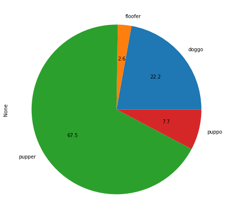

```python
# plot the data

df_master.groupby('dog_breed').size().plot(figsize = (12,8), kind='pie', autopct='%.1f')
```

### 2- Which breeds are highly rated ?

```python
# write the code

df_master.groupby(['dog_breed', 'rating_numerator','rating_denominator']).name.agg('max')
```

```
dog_breed  rating_numerator  rating_denominator
doggo      8.0               10.0                    Kellogg
           10.0              10.0                        his
           11.0              10.0                     Wishes
           12.0              10.0                       just
           13.0              10.0                       Sobe
           14.0              10.0                        one
floofer    10.0              10.0                      Moose
           11.0              10.0                    Petrick
           12.0              10.0                        Doc
           13.0              10.0                  Grizzwald
pupper     3.0               10.0                       Phil
           6.0               10.0                     Norman
           7.0               10.0                    Patrick
           8.0               10.0                        the
           9.0               10.0                        Zoe
           10.0              10.0                        the
           11.0              10.0                     Winnie
           12.0              10.0                       just
           13.0              10.0                        Jed
           14.0              10.0                          a
           27.0              10.0                     Sophie
puppo      9.0               10.0                       Abby
           10.0              10.0                       Kilo
           11.0              10.0                     Bayley
           12.0              10.0                     Shikha
           13.0              10.0                      Tonks
Name: name, dtype: object
```

```python
# write the code

df_top10=df_master.loc[df_master['rating_numerator']== 10 ,['dog_breed','rating_numerator']]

# check
df_top10.head(10)
```

|  | dog_breed | rating_numerator |
| --- | --- | --- |
| 61 | doggo | 10.0 |
| 62 | pupper | 10.0 |
| 80 | puppo | 10.0 |
| 88 | doggo | 10.0 |
| 89 | doggo | 10.0 |
| 91 | puppo | 10.0 |
| 103 | floofer | 10.0 |
| 105 | pupper | 10.0 |
| 109 | pupper | 10.0 |
| 112 | pupper | 10.0 |

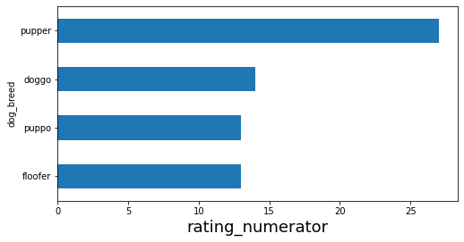

```python
# plot the data

x = df_master.groupby('dog_breed')['rating_numerator'].max().sort_values()
plt.figure(figsize = (8,4))

plt.xlabel('rating_numerator', fontsize = 18);
x.plot(kind='barh')
```

### 3- The relationship between favorite and retweet

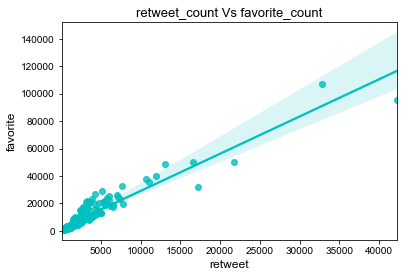

```python
# write the code

ax = sns.regplot(x=df_master['retweet_count'],y=df_master['favorite_count'],color='c')

#define the title and the labels of the scatter plot.
ax.set_title("retweet_count Vs favorite_count",fontsize=13)
ax.set_xlabel("retweet",fontsize=12)
ax.set_ylabel("favorite",fontsize=12)

#define the figure size.
sns.set(rc={'figure.figsize':(3,2)})
sns.set_style("whitegrid")
```

**4- What is the most common gender ?**

```python
# write the code

male_pronouns = ['He', 'he', 'him', 'his', "he's", 'himself']
female_pronouns = ['She', 'she', 'her', 'hers', 'herself', "she's"]

gender = []

for text in df_master['text']:
    # Male
    if any(map(lambda v:v in male_pronouns, text.split())):
        gender.append('male')
    # Female
    elif any(map(lambda v:v in female_pronouns, text.split())):
        gender.append('female')
    # If group or not specified
    else:
        gender.append('NaN')

#define a new column for dog gender
df_master['dog_gender'] = gender
```

```python
# drop 'NaN' values
df_master = df_master.replace(to_replace='NaN', value=np.nan).dropna()
```

```python
# write the code

df_master.dog_gender.value_counts()
```

```
male      75
female    27
Name: dog_gender, dtype: int64
```

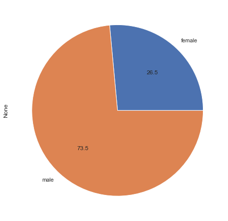

```python
# plot the data
df_master.groupby('dog_gender').size().plot(figsize = (12,8), kind='pie', autopct='%.1f')
```

### 5- What are the most common names for dogs?

```python
# browes and count the unique names
names=df_master.name.unique()
names
```

```
array(['Cassie', 'Stuart', 'Yogi', 'Grizzwald', 'Jed', 'Sebastian',
       'Sierra', 'Rover', 'Scout', 'Shikha', 'Jamesy', 'Barney', 'Mimosa',
       'Pickles', 'Clark', 'Meera', 'Ava', 'Rhino', 'Miguel', 'Emanuel',
       'Pete', 'Doobert', 'Kona', 'Loki', 'Cupid', 'Pilot', 'Gabe',
       'Duchess', 'Oliver', 'Sunny', 'Bo', 'Cooper', 'Chubbs', 'Rocky',
       'Craig', 'Ollie', 'Diogi', 'Doc', 'Laika', 'Lily', 'Tonks',
       'Rizzo', 'Sampson', 'Anakin', 'Finley', 'Winnie', 'Chelsea',
       'Willem', 'Wishes', 'Jax', 'Milo', 'Zoe', 'his', 'Abby', 'Kilo',
       'Edmund', 'Aqua', 'Benji', 'Bayley', 'Kellogg', 'Buckley', 'Kyle',
       'Rooney', 'Rueben', 'Luther', 'Derek', 'Winston', 'Chuckles',
       'Adele', 'Ralphson', 'Sansa', 'Millie', 'Lorenzo', 'Grady', 'Trip',
       'Blakely', 'Olivia', 'Birf', 'Marty', 'Otis', 'Hubertson',
       'Gerbald', 'Larry', 'Charlie', 'Hector', 'Kawhi', 'Bella',
       'Godzilla', 'Pepper', 'Zuzu', 'Mollie', 'Superpup', 'Rufio',
       'Obie', 'Scott', 'Jazz', 'Rolf', 'Bubba'], dtype=object)
```

```python
# drop 'NaN' values

df_master = df_master.replace(to_replace='a' , value='nan').dropna()
df_master = df_master.replace(to_replace='his', value='nan').dropna()
df_master = df_master.replace(to_replace='the', value='nan').dropna()
df_master = df_master.replace(to_replace='all', value='nan').dropna()
df_master = df_master.replace(to_replace='one', value='nan').dropna()
df_master = df_master.replace(to_replace='just', value='nan').dropna()
```

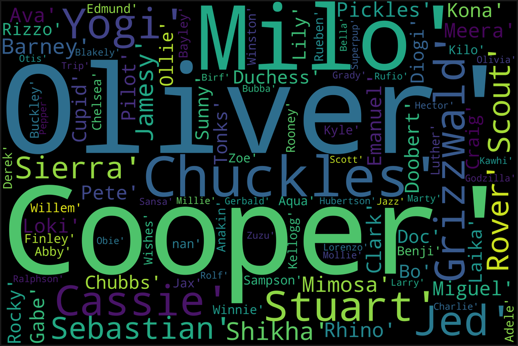

```python
# display the names
# write the code

from wordcloud import WordCloud, STOPWORDS
import matplotlib.pyplot as plt
text = df_master.name.values
wordcloud = WordCloud(
    width = 3000,
    height = 2000,
    background_color = 'black',
    stopwords = STOPWORDS).generate(str(text))
fig = plt.figure(
    figsize = (40, 30),
    facecolor = 'k',
    edgecolor = 'k')
plt.imshow(wordcloud, interpolation = 'bilinear')
plt.axis('off')
plt.tight_layout(pad=0)

# show the plot
plt.show()
```

### What is the highest and lowest retweeted tweet ?

```python
# Highest retweeted tweet
df_master.sort_values('retweet_count', ascending=False)[['tweet_id','retweet_count']].head()
```

|  | tweet_id | retweet_count |
| --- | --- | --- |
| 42 | 819004803107983360 | 42228 |
| 16 | 866450705531457537 | 32883 |
| 41 | 819006400881917954 | 21794 |
| 37 | 822462944365645825 | 17209 |
| 18 | 846514051647705089 | 13076 |

```python
# check
df_master.sort_values('retweet_count', ascending=True)[['tweet_id','retweet_count']].head()
```

|  | tweet_id | retweet_count |
| --- | --- | --- |
| 171 | 674737130913071104 | 103 |
| 190 | 672481316919734272 | 137 |
| 169 | 675006312288268288 | 252 |
| 121 | 704347321748819968 | 393 |
| 193 | 672160042234327040 | 395 |

### The source of interaction on Twitter.

```python
# write the code

df_master.source.value_counts()
```

```
Twitter for iPhone    102
Name: source, dtype: int64
```

## Resources :

https://en.wikipedia.org/wiki/WeRateDogs

https://studyingdata.com/data_analysis_files/wrangle_act_weratedogs.html

https://github.com/NadimKawwa